## **Modelado Estadistico**

### Regresion Linear Simple

```r
data_mundial <- read.csv("https://bitsandbricks.github.io/data/gapminder.csv")
summary(data_mundial)
```

```
          pais         continente       aÃ.o         expVida
 Afghanistan:  12   Africa  :624   Min.   :1952   Min.   :23.60
 Albania    :  12   Americas:300   1st Qu.:1966   1st Qu.:48.20
 Algeria    :  12   Asia    :396   Median :1980   Median :60.71
 Angola     :  12   Europe  :360   Mean   :1980   Mean   :59.47
 Argentina  :  12   Oceania : 24   3rd Qu.:1993   3rd Qu.:70.85
 Australia  :  12                  Max.   :2007   Max.   :82.60
 (Other)    :1632
      pobl                PBI_PC
 Min.   :     60011   Min.   :   241.2
 1st Qu.:   2793664   1st Qu.:  1202.1
 Median :   7023596   Median :  3531.8
 Mean   :  29601212   Mean   :  7215.3
 3rd Qu.:  19585222   3rd Qu.:  9325.5
 Max.   :1318683096   Max.   :113523.1
```

Con el poder de `summary()`, podemos decir unas cuantas cosas acerca de nuestros dataset. Las observaciones son de un país, su continente, un año determinado y su expectativa de vida, población y… ¿PBI_PC?. Esa última es PBI per cápita. Que, según parece, hay 12 observaciones por país. Que el rango de años es de 1952 a 2007. Que a lo largo de esos años, la menor expectativa registrada ha sido de 23 años (¡uf!) y la mayor de 82. Que el país menos poblado en el dataset ha tenido apenas más de 60.000 habitantes, mientras que el más populoso ha alcanzado los 1300 millones.

#### **Regresion con una variable numerica**

```r
data_arg <- data_mundial %>%
    filter(pais == "Argentina")
data_arg
```

| pais | continente | aÃ.o | expVida | pobl | PBI_PC |
| --- | --- | --- | --- | --- | --- |
| Argentina | Americas | 1952 | 62.485 | 17876956 | 5911.315 |
| Argentina | Americas | 1957 | 64.399 | 19610538 | 6856.856 |
| Argentina | Americas | 1962 | 65.142 | 21283783 | 7133.166 |
| Argentina | Americas | 1967 | 65.634 | 22934225 | 8052.953 |
| Argentina | Americas | 1972 | 67.065 | 24779799 | 9443.039 |
| Argentina | Americas | 1977 | 68.481 | 26983828 | 10079.027 |
| Argentina | Americas | 1982 | 69.942 | 29341374 | 8997.897 |
| Argentina | Americas | 1987 | 70.774 | 31620918 | 9139.671 |
| Argentina | Americas | 1992 | 71.868 | 33958947 | 9308.419 |
| Argentina | Americas | 1997 | 73.275 | 36203463 | 10967.282 |

[output cut: 2 more lines]

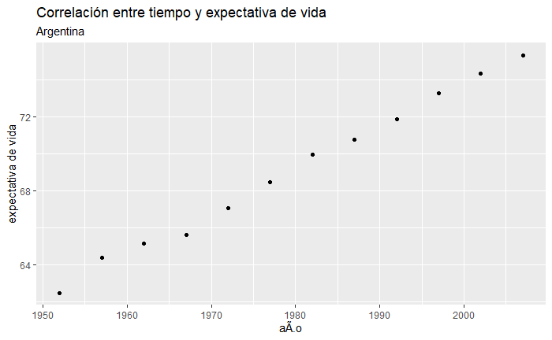

```r
ggplot(data = data_arg) +
    geom_point(aes(x = aÃ.o, y = expVida)) +
    labs(title = "Correlación entre tiempo y expectativa de vida",
         subtitle = "Argentina",
         y = "expectativa de vida")
```

```r
cor(data_arg$aÃ.o, data_arg$expVida)
```

```
[1] 0.9977816
```

Vamos a la regresión lineal entonces, para medir de una buena vez la correlación entre tiempo y expectativa de vida. Usamos la función lm() (por “linear model”), así:

```r
modelo_exp <- lm(expVida ~ aÃ.o, data = data_arg)
```

Obsérvese que volvió aparecer el simbolillo que denota una fórmula, `~`. Usado como primer argumento de `lm()`, significa “expVida vs año”, es decir “estimar el efecto en la variable expVida cuando incrementa el valor de año”, usando los datos contenidos en el dataframe data_arg.

```r
modelo_exp
```

```
Call:
lm(formula = expVida ~ aÃ.o, data = data_arg)

Coefficients:
(Intercept)         aÃ.o
  -389.6063       0.2317
```

> En nuestro modelo, el coeficiente de la variable “año” es 0.2317. Significado: incrementando en una unidad la variable año, la variable expectativa de vida se incrementa en 0.2317. Dicho de otra manera, por cada año que pasa la expectativa de vida en la Argentina aumenta casi 3 meses.

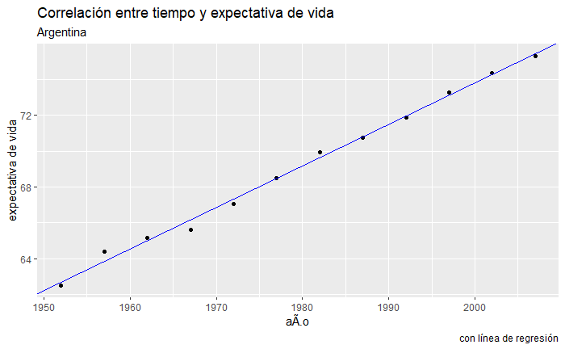

```r
ggplot(data = data_arg) +
    geom_point(aes(x = aÃ.o, y = expVida)) +
    labs(title = "Correlación entre tiempo y expectativa de vida",
         subtitle = "Argentina",
         y = "expectativa de vida",
         caption = "con línea de regresión") +
    geom_abline(aes(intercept = -389.6063, slope = 0.2317), color = "blue")
```

Aquí no vemos más que los datos que ya teníamos. Pero proyectemos la línea hacia el futuro. Con xlim() e ylim() podemos definir a mano los límites de nuestro gráfico, haciéndolo ir más allá del rango de los datos que tenemos. La línea sigue siendo la misma, sólo que ahora podemos ver hacia donde va.

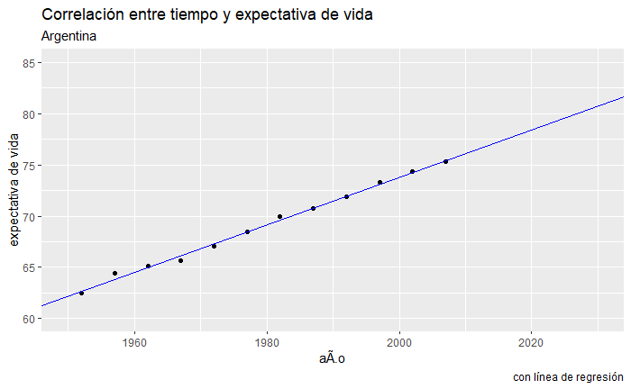

```r
ggplot(data = data_arg) +
    geom_point(aes(x = aÃ.o, y = expVida)) +
    labs(title = "Correlación entre tiempo y expectativa de vida",
         subtitle = "Argentina",
         y = "expectativa de vida",
         caption = "con línea de regresión") +
    geom_abline(aes(intercept = -389.6063, slope = 0.2317), color = "blue") +
    xlim(c(1950, 2030)) +
    ylim(c(60, 85))
```

> Según nuestro modelo, para el año 2030 la expectativa de vida en la Argentina habrá superado los 80 años.